# Lecture 14 Examples

Christopher Prener, Ph.D.

(November 26, 2018)

## Introduction

This notebook provides examples of the syntax described in Lecture 14.

## Dependencies

This notebook requires quite a few packages for assessing regression models:

```r
# tidyverse packages
library(dplyr)      # data wrangling
library(ggplot2)    # mpg data
library(tibble)     # data wrangling

# statistics packages
library(car)        # regression diagnostics
library(heplots)    # effect sizes
library(lmtest)     # white's test
library(sandwich)   # robust standard errors

# other packages
library(here)       # file path management
library(stargazer)  # regression output
```

To simplfy printing output, we’re going to define a quick function. For each of the tests we’re using, we’ll store the id numbers of problematic observations in an object. We’ll then print the data for each problematic observation:

```r
printObs <- function(.data, values){

  .data %>%
    filter(row_number() %in% values) %>%
    select(id, manufacturer, model, hwy, displ, cyl)

}
```

## Load Data

This notebook requires data from the `ggplot2` package:

```r
autoData <- mpg
```

## Initial Modeling

### Model 1

This model estimates the effect of engine size on highway fuel efficiency:

```r
model1 <- lm(hwy ~ displ+cyl, data = autoData)
```

As a quick review, we can view the model’s main findings with the `summary()` function:

```r
summary(model1)
```

```
Call:
lm(formula = hwy ~ displ + cyl, data = autoData)

Residuals:
    Min      1Q  Median      3Q     Max
-7.5098 -2.1953 -0.2049  1.9023 14.9223

Coefficients:
            Estimate Std. Error t value Pr(>|t|)
(Intercept)  38.2162     1.0481  36.461  < 2e-16 ***
displ        -1.9599     0.5194  -3.773 0.000205 ***
cyl          -1.3537     0.4164  -3.251 0.001323 **
---
Signif. codes:  0 ‘***’ 0.001 ‘**’ 0.01 ‘*’ 0.05 ‘.’ 0.1 ‘ ’ 1

Residual standard error: 3.759 on 231 degrees of freedom
Multiple R-squared:  0.6049,    Adjusted R-squared:  0.6014
F-statistic: 176.8 on 2 and 231 DF,  p-value: < 2.2e-16
```

Both displacement ($\beta = -1.960, p = 0.0002$) and the number of cylinders ($\beta = -1.354, p = 0.001$) are associated with decreases in fuel efficiency - as engine size increases, fuel efficiency decreases. These two factors explain approximately 60% of the variance in highway fuel efficiency.

### New Operators

In order to assess the fit and assumptions for model 1, we need a few new tools. The first is `which()`, which prints row numbers for observations that fit a particular condition:

```r
(highmpg <- which(autoData$hwy > 40))
```

```
[1] 213 222 223
```

There are three observations that have a highway fuel effiency of more than 40 miles per gallon - rows 213, 222, and 223.

We can easily subset using these values if we wanted to see some details about them. The `%in%` operator creates a logical test - are values in a given set listed *in* an object. In this case, we test whether any of the row numbers are listed in the `highmpg` object we created above.

```r
filter(autoData, row_number() %in% highmpg)
```

| manufacturer | model | displ | year | cyl | trans | drv | cty | hwy | fl | class |
| --- | --- | --- | --- | --- | --- | --- | --- | --- | --- | --- |
| volkswagen | jetta | 1.9 | 1999 | 4 | manual(m5) | f | 33 | 44 | d | compact |
| volkswagen | new beetle | 1.9 | 1999 | 4 | manual(m5) | f | 35 | 44 | d | subcompact |
| volkswagen | new beetle | 1.9 | 1999 | 4 | auto(l4) | f | 29 | 41 | d | subcompact |

The three highest fuel effieciency vehicles are late 1990s era Volkswagen models.

We can also create an ID number column from the row numbers. This will be useful later:

```r
autoData %>%
  rowid_to_column("id") %>%
  select(id, everything()) -> autoData
```

This new column’s values are based entirely on the sort order - if the sort order changes, these values will be applied differently.

## Checking Assumptions

### Non-Linearity

We can use scatterplots with regression lines fit to test for non-linearity. We can also use component+residual plots, which plot the residuals from a given independent variable against the dependent variable. The plots show the best fit line for both the residuals and the component (a hypothetical linear relationship) - the larger the difference between these two lines, the less confident we can be that a linear model is most appropriate for these data.

This is the plot for our model:

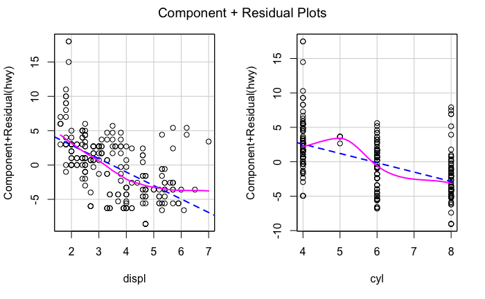

```r
crPlots(model1)
```

The plot on the left is the one we’ll focus on since it is continuous. You can see the pink line deviate upwards on the right side of the plot- that is the impact of sports cars that we have noted in past explorations of these data. Overall, these plots do not suggest that non-linearity is a serious concern. If it were, we would want to statistically transform these variables (such as taking the square root, squaring, or taking the natural log).

In large models, it is more useful to print one plot at a time for the continuous relationships:

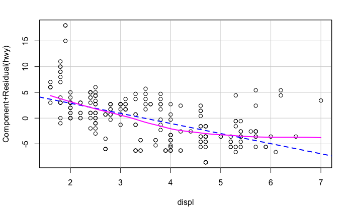

```r
crPlot(model1, variable="displ")
```

### Outlier Detection

The Bonferonni test will identify outliers by observation. The `outlierTest()` output will show statistically significant observations, each of which is considered an outlier:

```r
outlierTest(model1)
```

|  | rstudent | unadjusted p-value | Bonferonni p |
| --- | --- | --- | --- |
| 213 | 4.127028 | 5.1401e-05 | 0.012028 |
| 222 | 4.127028 | 5.1401e-05 | 0.012028 |

We can learn more about these observations by extracting the row numbers from the output and then using `filter()` along with the `row_number() %in%` syntax we’ve used above:

```r
bonferonni <- outlierTest(model1)
bonferonni <- as.numeric(attr(bonferonni$p, "names"))

printObs(autoData, bonferonni)
```

| id | manufacturer | model | hwy | displ | cyl |
| --- | --- | --- | --- | --- | --- |
| 213 | volkswagen | jetta | 44 | 1.9 | 4 |
| 222 | volkswagen | new beetle | 44 | 1.9 | 4 |

Two of the Volkswagen vehicles are identified as outliers here. These are the two vehicles with the highest fuel efficiency in the data set:

```r
autoData %>%
  arrange(desc(hwy)) %>%
  select(id, manufacturer, model, hwy, displ, cyl)
```

| id | manufacturer | model | hwy | displ | cyl |
| --- | --- | --- | --- | --- | --- |
| 213 | volkswagen | jetta | 44 | 1.9 | 4 |
| 222 | volkswagen | new beetle | 44 | 1.9 | 4 |
| 223 | volkswagen | new beetle | 41 | 1.9 | 4 |
| 197 | toyota | corolla | 37 | 1.8 | 4 |
| 106 | honda | civic | 36 | 1.8 | 4 |
| 107 | honda | civic | 36 | 1.8 | 4 |
| 196 | toyota | corolla | 35 | 1.8 | 4 |
| 198 | toyota | corolla | 35 | 1.8 | 4 |
| 105 | honda | civic | 34 | 1.8 | 4 |
| 100 | honda | civic | 33 | 1.6 | 4 |

[output cut: 224 more lines]

Before we move on, we’ll want to note the id numbers for the two observations for later.

### Unusual Observations

We have three techniques at our disposal for identifying observations that are “unusual” in some way - i.e. they exert too much influence on the model because of their particular combination of values.

#### Leverage

To calculate leverage, we’ll use the equation:

$\frac{2*p}{n}$

We can calculate $p$ (the number of parameters) and $n$ (the number of observations in the model) automatically using the syntax below - we need to pull information from the `model1` object.

```r
p <- as.numeric(length(attr(model1$coefficients, "names")))
n <- as.numeric(nrow(model1$model))

leveragePoints2 <- which(hatvalues(model1) > (2*p)/n)

printObs(autoData, leveragePoints2)
```

| id | manufacturer | model | hwy | displ | cyl |
| --- | --- | --- | --- | --- | --- |
| 23 | chevrolet | c1500 suburban 2wd | 17 | 6.0 | 8 |
| 26 | chevrolet | corvette | 26 | 6.2 | 8 |
| 27 | chevrolet | corvette | 25 | 6.2 | 8 |
| 28 | chevrolet | corvette | 24 | 7.0 | 8 |
| 32 | chevrolet | k1500 tahoe 4wd | 17 | 6.5 | 8 |
| 130 | jeep | grand cherokee 4wd | 14 | 6.1 | 8 |
| 131 | land rover | range rover | 15 | 4.0 | 8 |

We can calculate a more conservative measure of leverage using the following equation:

$\frac{3*p}{n}$

We’ll use the same values for $p$ and $n$ we’ve stored earlier:

```r
leveragePoints3 <- which(hatvalues(model1) > (3*p)/n)

printObs(autoData, leveragePoints3)
```

| id | manufacturer | model | hwy | displ | cyl |
| --- | --- | --- | --- | --- | --- |
| 28 | chevrolet | corvette | 24 | 7.0 | 8 |
| 32 | chevrolet | k1500 tahoe 4wd | 17 | 6.5 | 8 |

We can see that there are two observations with a high degree of leverage on the model and another five that have a smaller but still notable amount of leverage. These observations tend to be vehicles with very large engines, the highest number of cylinders, and very low highway fuel efficiency. We’ll note the observation numbers for both sets of leverage output as we did for outliers above.

We can also display these visually using the following syntax:

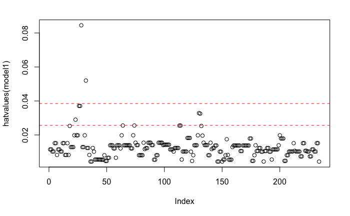

```r
plot(hatvalues(model1))
abline(h = c(2,3)*p/n, col="red", lty=2)
```

We can see that there are another 5 observations that very nearly cross the threshold into being “high leverage” observations.

#### Cook’s Distance

Cook’s distance is an alternative measure of influence. We are particularly concerned about observations that have a value for Cook’s distance greater than 1:

```r
cooksD1 <- which(cooks.distance(model1) > 1)

printObs(autoData, cooksD1)
```

| id | manufacturer | model | hwy | displ | cyl |
| --- | --- | --- | --- | --- | --- |

The `0 rows` output means that there are no observations that meet this criteria.

We should also be concerned about observations that have a Cook’s distance greater than .5:

```r
cooksDHalf <- which(cooks.distance(model1) > .5)

printObs(autoData, cooksDHalf)
```

| id | manufacturer | model | hwy | displ | cyl |
| --- | --- | --- | --- | --- | --- |

Again, there are no observations that meet this criteria.

We can visual the Cook’s distance values with the following syntax:

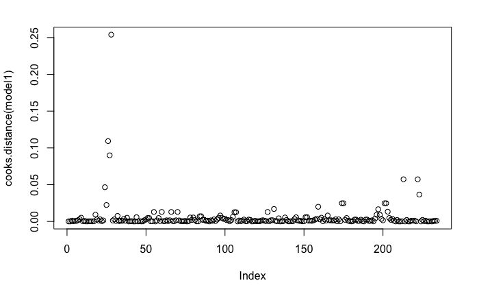

```r
plot(cooks.distance(model1))
abline(h = c(1, .5), col="red", lty=2)
```

We don’t see either of our red lines because none of the observations meet the criteria of being greater than .5 or 1. We should, however, note observations that do not cross this threshold but are outliers relative to the other observations in the data set. There are three points that stand out, and we can identify them by setting our value for Cook’s distance based on the y axis of the plot:

```r
cooksDBorderline <- which(cooks.distance(model1) > .08)

printObs(autoData, cooksDBorderline)
```

| id | manufacturer | model | hwy | displ | cyl |
| --- | --- | --- | --- | --- | --- |
| 26 | chevrolet | corvette | 26 | 6.2 | 8 |
| 27 | chevrolet | corvette | 25 | 6.2 | 8 |
| 28 | chevrolet | corvette | 24 | 7.0 | 8 |

These three borderline values should be noted for later reference.

#### Influence Plots

The influence plot combines measures of Cook’s Distance and “studentized resiudals” (residuals converted to $t$ values) and notes particularly extreme observations:

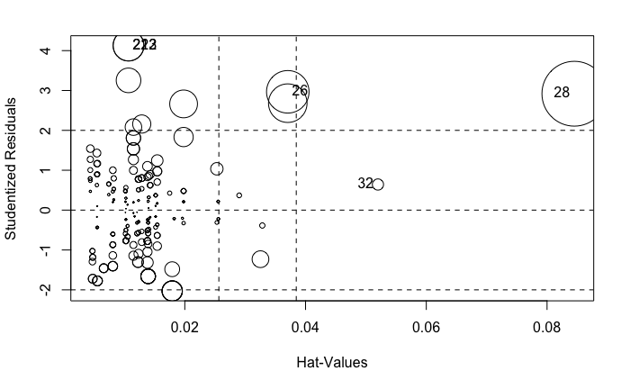

```r
influence <- influencePlot(model1)
```

The plot shows us the comparison of our estimated values with the studentized resiudals. Sometimes the output is difficult to read, however, so it is easier to store the row numbers and print the corresponding observations:

```r
influenceObs <- as.integer(row.names(influence))

printObs(autoData, influenceObs)
```

| id | manufacturer | model | hwy | displ | cyl |
| --- | --- | --- | --- | --- | --- |
| 26 | chevrolet | corvette | 26 | 6.2 | 8 |
| 28 | chevrolet | corvette | 24 | 7.0 | 8 |
| 32 | chevrolet | k1500 tahoe 4wd | 17 | 6.5 | 8 |
| 213 | volkswagen | jetta | 44 | 1.9 | 4 |
| 222 | volkswagen | new beetle | 44 | 1.9 | 4 |

We have five observations that have a high degree of influence on our model. Again, we’ll note the observation numbers before moving on.

### Normality of Residuals

Our model’s residuals should be normally distributed. The `car` package contains a special `qqPlot` function for assessing this, which includes additional lines on the plot for assessing deviations from normality:

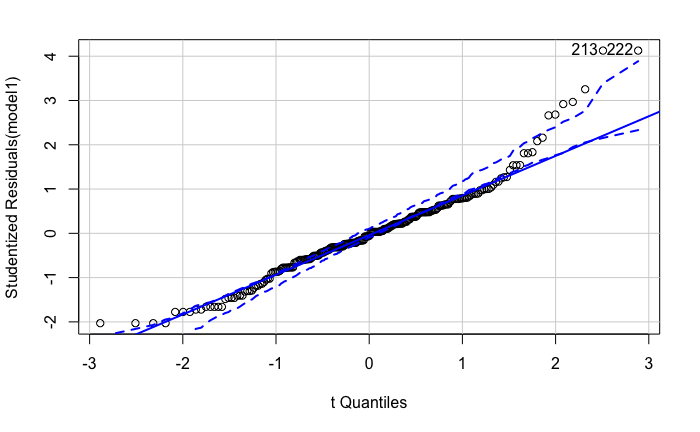

```r
qqplot <- qqPlot(model1)
```

We can print the observations identified as problematic using the `qqplot` object we’ve created above:

```r
printObs(autoData, qqplot)
```

| id | manufacturer | model | hwy | displ | cyl |
| --- | --- | --- | --- | --- | --- |
| 213 | volkswagen | jetta | 44 | 1.9 | 4 |
| 222 | volkswagen | new beetle | 44 | 1.9 | 4 |

As before, we’ll note the problematic observations. We’ll also want to note that our residuals are not normally distributed.

### Homoskedastic Errors

We want the variance in our residual error to be constant (i.e. heteroskedastic). We can use both a hypothesis test and a plot to diagnose possible homoskedastic error.

#### Breusch-Pagan Test

If the residuals are normally distributed, then we want to use the the Breusch-Pagan Test to diagnose homoskedasticity:

```r
bptest(model1)
```

```
    studentized Breusch-Pagan test

data:  model1
BP = 8.5133, df = 2, p-value = 0.01417
```

The statistically significant result here is *not* the most appropriate one to assess for our model give then prior results of the `qqPlot()`. Nevertheless, we can interpret the findings as a suggestion that homoskedasticity is a concern given the results of the Breusch-Pagan Test ($BP = 8.513, p = 0014$).

#### White’s Test

If the residuals are not normally distributed, then we want to use the White’s Test variant of the Breusch-Pagan Test.

```r
bptest(model1, ~ displ * cyl + I(displ^2) + I(cyl^2), data = autoData)
```

```
    studentized Breusch-Pagan test

data:  model1
BP = 16.022, df = 5, p-value = 0.00678
```

The statistically significant result here is the most appropriate one to assess for our model give then prior results of the `qqPlot()`. The White’s test ($BP = 16.022, p = 0.007$) suggests that homoskedasticity is a concern.

#### Residual Plot

When we create a residual plot, we are looking for any narrowing across the plot (see lecture slides).

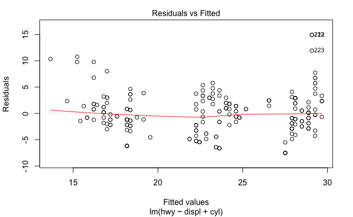

```r
plot(model1, which = 1)
```

This plot shows a small degree of narrowing, suggesting that homoskedasticity is present but not a significant conern. The plot identifies three observations - 213, 222, and 223 (these are hard to read) - that may be contributing to this condition. Since there is no output to save, we can create our own object:

```r
homoskedastic <- c(213, 222, 223)

printObs(autoData, homoskedastic)
```

| id | manufacturer | model | hwy | displ | cyl |
| --- | --- | --- | --- | --- | --- |
| 213 | volkswagen | jetta | 44 | 1.9 | 4 |
| 222 | volkswagen | new beetle | 44 | 1.9 | 4 |
| 223 | volkswagen | new beetle | 41 | 1.9 | 4 |

Again, we can note these observations for later.

### Auto-Correlation

The Durbin-Watson Test identifies the presence of auto-correlation in our model - the residuals are correlated with each other:

```r
durbinWatsonTest(model1)
```

```
 lag Autocorrelation D-W Statistic p-value
   1        0.534405     0.9284804       0
 Alternative hypothesis: rho != 0
```

The results of the Durbin-Watson Test ($DW = 0.928, p < .001$) suggest that auto-correlation is a concern.

*If you are using data measured in space, such as at the census tract level, you want to be sensitive to spatial autocorrelation as well. This occurs when observations are clustered near other like observations. Moran’s I is used to diagnose this condition and can be calculated in `R`, though I prefer the Python implementation from the `pysal` package.*

### Multi-Collinearity

We use the square root of the variance inflation factor (“VIF”) to identify multi-collinearity. Individual values should be less than 10:

```r
sqrt(vif(model1))
```

```
   displ      cyl
2.724912 2.724912
```

This measure indicates that multi-collinearity is not a significant concern. We also want our mean VIF to be less than 1:

```r
mean(sqrt(vif(model1)))
```

```
[1] 2.724912
```

This indicates that there is some minimal concern that our average level of multicollinearity is high but not problematically so. We could look for alternative model specifications if this were a more significant concern (by either creating scales or by changing the specific independent variables used).

## Adjusting Models

We need to deal with a number of problematic observations - 26, 27, 28, 32, 213, and 222. We also need to deal with broader model specification issues related to auto-correlation and multi-collinearity.

### Fitting on a Subset

First, we want to create a subset of our data that does not include potentially problematic observations.

```r
flaggedObs <- c(26, 27, 28, 32, 213, 222)

autoData %>%
  mutate(insample = ifelse(id %in% flaggedObs, TRUE, FALSE)) %>%
  filter(insample == FALSE) %>%
  select(-insample) -> autoDataSub

model2 <- lm(hwy ~ displ+cyl, data = autoDataSub)

aic2 <- round(AIC(model2), digits = 3)
bic2 <- round(BIC(model2), digits = 3)
```

We want to compare two things: (1) has the overall “story” of the model change in terms of significance, direction of betas, and adjsuted r-squared as well as (2) has model fit improved. This is easiest to assess in a formatted table, which we’ll create using `stargazer`.

Before we create the table, we need to calculate AIC and BIC values for model 1:

```r
aic1 <- round(AIC(model1), digits = 3)
bic1 <- round(BIC(model1), digits = 3)
```

Now we’re ready to create the table:

```r
stargazer(model1, model2,
  title = "Regression Results",
  add.lines = list(c("AIC", aic1, aic2),c("BIC", bic1, bic2)),
  omit.stat = "rsq", df = FALSE,
  type = "html", out = here("examples", "models.html"))
```

We can see that there have been shifts in the magnitude of the betas - the estimated effect of displacement on highway fuel efficiency has increased while the estimated effect of cylinder count has shrunk considerably. The standard errors on both betas have also shrunk. We also see across the board improvements in model fit (judged by AIC, BIC, and root mean squared error). Model 2 therefore appears to be a better fit than Model 1.

### Follow-up

We’ll want to do follow-up on whether normality, homoskedasticity, and auto-correlation remain concerns in model 2. If there are any outstanding concerns, we’ll want to fit our model using robust standard errors. We’ll start with normality:

```
[1]  24 217
```

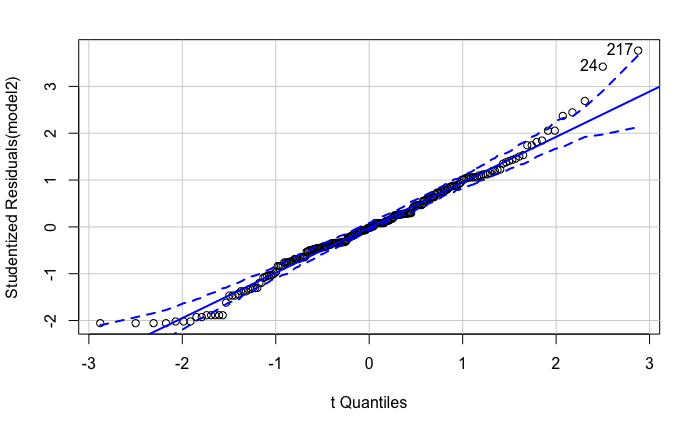

```r
qqPlot(model2)
```

This suggests we (a) still have concerns about our residuals’ distribution and (b) should use the White’s Test to follow-up on homoskedasticity:

```r
bptest(model2, ~ displ * cyl + I(displ^2) + I(cyl^2), data = autoDataSub)
```

```
    studentized Breusch-Pagan test

data:  model2
BP = 3.8338, df = 5, p-value = 0.5736
```

The results of the White’s Test ($BP = 3.834, p = 0.574$) suggest that we have managed concerns with homoskedasticity. Finally, we’ll check on auto-correlation for the new model:

```r
durbinWatsonTest(model2)
```

```
 lag Autocorrelation D-W Statistic p-value
   1       0.4893854      1.016667       0
 Alternative hypothesis: rho != 0
```

The results of the Durbin-Watson Test ($DW = 1.017, p < 0.001$) suggest that auto-correlation remains a concern. We should therefore fit our final model using robust standard errors.

### Robust Standard Errors

We can calculate an alternative set of standared errors and p-values using `coeftest` and an alternative covariance matrix estimate that gives us a more conservative estimate of statistical significance:

```r
coeftest(model2, vcov = vcovHC(model2, "HC3"))
```

```
t test of coefficients:

            Estimate Std. Error t value  Pr(>|t|)
(Intercept) 37.26018    0.94282 39.5199 < 2.2e-16 ***
displ       -2.98126    0.48570 -6.1381 3.733e-09 ***
cyl         -0.64042    0.37304 -1.7168    0.0874 .
---
Signif. codes:  0 ‘***’ 0.001 ‘**’ 0.01 ‘*’ 0.05 ‘.’ 0.1 ‘ ’ 1
```

We see here that the `cyl` results are not statisticaly significant to at least the $p < .05$ level. These output cannot be fed to `stargazer()`, so you should manually change the standard errors and p-values on a copy of the output you created above.

## Effect Sizes

Finally, we want to identify the “real world” significance of our findings by using eta-squared effect sizes:

```r
etasq(model2, partial = FALSE)
```

|  | eta^2 |
| --- | --- |
| displ | 0.13522785 |
| cyl | 0.01042765 |
| Residuals | NA |

The effect of displacement on highway fuel efficiency is moderate, while the effect of cylinder size is quite small.